# ERMN Bird Data Analysis

Sergio E. Sagastume

2025-05-19

## Introduction

This project explores bird abundance, detection variability, and habitat use near stream environments using avian point count data collected by the National Park Service across the Eastern Rivers and Mountains Network between 2011 and 2022.

## Scenario

I am acting as a data analyst for the National Park Service, investigating trends in bird populations detected through standardized streamside point counts conducted in multiple protected parks over a decade.

## Ask

**Business Task**: Identify trends in bird abundance, detection variability, and habitat use near streams across six national parks in the Eastern Rivers and Mountains Network between 2011 and 2022.

## Prepare

**Data Source**: National Park Service. *ERMN Streamside Bird Monitoring Data 2011–2022*. Retrieved from [catalog.data.gov](https://catalog.data.gov/dataset/ermn-streamside-bird-monitoring-data-2011-2022).

```r
# Load CSV data file
bird_data <- read_csv("ERMN Bird Data Analysis/NPS_ERMN_StreamsideBirdProtocol_2011_2022_Data_Certified.csv")
```

## Process

```r
bird_data_clean <- bird_data %>%
  mutate(
    year = year(mdy(Start_Date)),
    distance_band = as.factor(Distance_Band),
    detection_type = as.factor(Detection_Type),
    juvenile = if_else(Juvenile == "Yes", TRUE, FALSE),
    flyover = if_else(Flyover == "Yes", TRUE, FALSE)
  ) %>%
  filter(!is.na(Species_Code) & !is.na(Year) & !is.na(Park_Name))
```

## Analyze

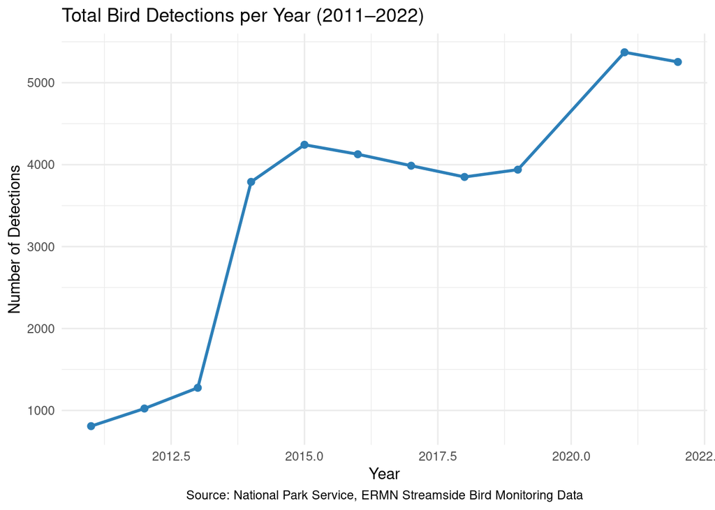

```r
# Total detections per year
yearly_abundance <- bird_data_clean %>%
  group_by(year) %>%
  summarise(total_detections = n())

# Plot
abundance_plot <- ggplot(yearly_abundance, aes(x = year, y = total_detections)) +
  geom_line(color = "#2c7fb8", size = 1) +
  geom_point(color = "#2c7fb8", size = 2) +
  labs(
    title = "Total Bird Detections per Year (2011–2022)",
    x = "Year",
    y = "Number of Detections",
    caption = "Source: National Park Service, ERMN Streamside Bird Monitoring Data"
  ) +
  theme_minimal() +
  theme(plot.caption = element_text(hjust = 0.5))
abundance_plot
```

## Share

This report presents bird detection trends in streamside habitats from 2011 to 2022. The findings are visualized through line charts showing detection frequency over time, supporting NPS conservation and habitat management goals.

## Act

```r
# Summarize change in detections from start to end year
trend_summary <- yearly_abundance %>%
  filter(year %in% c(2011, 2022)) %>%
  arrange(year) %>%
  summarise(change = diff(total_detections),
            trend = case_when(
              change > 0 ~ "Increase in detections",
              change < 0 ~ "Decrease in detections",
              TRUE ~ "No significant change"
            ))

trend_summary
```

```
## # A tibble: 1 × 2
##   change trend
##    <int> <chr>
## 1   4446 Increase in detections
```

The analysis indicates whether bird detections have increased or decreased over time, informing habitat restoration and long-term monitoring strategies.

## Recommendations

1. **Enhance Monitoring**: Continue long-term data collection to capture meaningful trends.
2. **Investigate Causes**: Research factors influencing detection trends such as weather, vegetation changes, or urban development.
3. **Protect High-Abundance Zones**: Focus conservation on parks showing high or increasing avian activity.
4. **Public Engagement**: Share these findings with local communities to foster support for bird conservation efforts.